# Cefepime Bayesian Meta-Analysis

- Show All Code
- Hide All Code
- View Source

Part I — Model Specification, Fit & Diagnostics

# 1 Packages

```r
### Install/Load packages
pacman::p_load(dplyr,
               tidyr,
               brms,
               bayesplot,
               tidybayes,
               ggplot2,
               here,
               MetBrewer,
               stringr,
               cmdstanr)

color_scheme_set("red")

theme_set(
  theme(
    plot.title.position = 'plot',
    axis.ticks.x = element_blank(),
    axis.ticks.y = element_blank(),
    axis.text.x = element_text(size = 12),
    axis.text.y = element_text(size = 12),
    axis.title.x = element_text(size = 14),
    panel.background = element_blank(),
    panel.grid.major.x = element_line(color = "gray80", linewidth = 0.3)
  )
)
```

# 2 Data

```r
data = read.csv(here("data/cef_dataonly.csv"), header=T)

# Risk of bias data
rob = read.csv(here("data/ROB_cefepime.csv"), header=T)

filtered_data =
  data |>
  left_join(rob, by = "Study.ID") |>
  filter(Comparator != "Control", #exclude sponsor studies
         N_cef != "NA") |>  # exclude studies with missing data
  rename("death_com" = deaths_com,
         "study" = Study.ID,
         "indication" = Intended.clinical.indication,
         "comparator_group" = Comparator.group,
         "population" = Patient.population,
         "overall_rob" = Overall.ROB)

long_data =
  filtered_data |>
  pivot_longer(
   cols = c(death_cef, death_com, N_cef, N_com),
   names_to = c(".value", "group"),
   names_sep = "_"
) |>
  # important for model fitting
  mutate(study = factor(study),
         treat = ifelse(group == "com", 0, 1) |> factor(levels = c("0", "1")),
         treat12 = ifelse(group == "com", -0.5, 0.5),

         indication = factor(indication,
                             levels = c("Febrile neutropenia",
                                        "Pneumonia",
                                        "Severe bacterial infections",
                                        "UTI",
                                        "Meningitis",
                                        "Mixed")),
         comparator_group = factor(comparator_group,
                                   levels = c("Piperacillin-tazobactam",
                                              "Carbapenem",
                                              "Cefotaxime/Ceftriaxone",
                                              "Ceftazidime")),
         population = factor(population,
                             levels = c("Adults",
                                        "Pediatrics")),
         Cefepime_q12 = factor(Cefepime_q12,
                               levels = c("High",
                                          "Low")),

         overall_rob = factor(overall_rob,
                              levels = c("Low",
                                         "Some concerns",
                                         "High"))
          )
```

# 3 Statistical Model

All analyses use a Bayesian binomial random-effects meta-analysis fit with `brms` via `cmdstanr`. We follow Model 4 of Jackson, Law, Stijnen, Viechtbauer & White (2018) [doi:10.1002/sim.7588](https://doi.org/10.1002/sim.7588), which models the treatment effect as a random deviation from a trial-specific baseline.

## 3.1 Likelihood and linear predictor

The model has three pieces. Each trial contributes a **control arm** and a **cefepime arm**, and the number of deaths in each arm is modelled as binomial. The log-odds of death in arm $j$ of trial $i$ are built from (1) a **trial-specific baseline** $\alpha_i$ that absorbs how sick that trial’s population is at baseline, (2) a **pooled treatment effect** $\theta$ — the quantity we want to estimate, and (3) a **trial-level deviation** $u_i$ that lets the true treatment effect vary across trials. The standard deviation $\tau$ of those deviations measures between-trial heterogeneity.

For trial $i$ and arm $j \in \{C, T\}$, with $y_{ij}$ deaths among $N_{ij}$ participants:

$$y_{ij} \sim \text{Binomial}(N_{ij},\,p_{ij})$$

$$\operatorname{logit}(p_{ij}) \;=\; \alpha_i \;+\; \theta\, T_{ij} \;+\; u_i\, z_{ij}$$

Corresponding `brms` formula:

```r
bf(death | trials(N) ~ 1 + study + treat + (treat12 - 1 | study))
```

where

- $\alpha_i$ — baseline (control-arm) log-odds of death in trial $i$, estimated separately for each trial (no normality assumption is imposed on baselines across trials);
- $\theta$ — pooled treatment log-odds ratio (primary estimand);
- $T_{ij} \in \{0,1\}$ — treatment indicator (0 = control, 1 = cefepime);
- $u_i \sim \mathcal N(0,\,\tau^2)$ — trial-specific deviation in the treatment effect, so trial $i$’s true log-odds ratio is $\theta + u_i$;
- $z_{ij} = -0.5$ for control, $+0.5$ for cefepime — contrast coding that keeps the random deviation symmetric around the baseline (Model 4 of Jackson et al.);
- $\tau$ — between-trial heterogeneity in the treatment effect.

## 3.2 Priors

$$\alpha_i \sim \mathcal{N}(0,\,1.5^2), \qquad
\theta \sim \mathcal{N}(0,\,0.82^2), \qquad
\tau \sim \text{Log-Normal}(-2.09,\,0.705^2).$$

The prior on $\tau$ is the informative all-cause-mortality, pharma-vs-pharma prior of Turner et al., obtained via `bayesmeta::TurnerEtAlPrior("all-cause mortality", "pharma", "pharma")`.

## 3.3 Subgroup meta-regressions

To check whether the treatment effect varies by a trial-level feature (e.g. clinical indication, comparator drug), we extend the model with an interaction between treatment and the subgroup variable. The logic is the same — one pooled effect, one heterogeneity term — but now the pooled effect is decomposed: $\theta$ is the treatment effect in the **reference subgroup**, and $\delta_k$ is how much the treatment effect **shifts** in subgroup $k$. So subgroup $k$’s treatment effect is $\theta + \delta_k$. A separate parameter $\gamma_k$ shifts the baseline log-odds for subgroup $k$, so the model doesn’t confuse “this subgroup has a different underlying risk” with “this subgroup responds differently to treatment”.

For trial $i$ in subgroup level $k \in \{1, \dots, K\}$ (with $k = 1$ the reference):

$$\operatorname{logit}(p_{ij}) \;=\; \alpha_i \;+\; \theta\, T_{ij} \;+\; \sum_{k=2}^{K}\!\left(\gamma_k \;+\; \delta_k\, T_{ij}\right) s_{ik} \;+\; u_i\, z_{ij},$$

Corresponding `brms` formula (with `indication` as the example subgroup):

```r
bf(death | trials(N) ~ 1 + study + treat * indication + (treat12 - 1 | study))
```

where $s_{ik} = 1$ if trial $i$ belongs to subgroup level $k$ (and 0 otherwise), with $\delta_1 \equiv 0$. Priors: $\gamma_k \sim \mathcal N(0,\,1.2^2)$ on subgroup baseline shifts, and $\delta_k \sim \mathcal N(0,\,0.3^2)$ — a regularising prior that pulls subgroup-specific treatment effects toward the pooled estimate unless the data argue otherwise.

**One model is fit per subgroup variable.** The six subgroup analyses are:

| Subgroup variable | Levels (reference first) |
| --- | --- |
| Clinical indication | Febrile neutropenia, Pneumonia, Severe bacterial infections, UTI, Meningitis, Mixed |
| Comparator group | Piperacillin–tazobactam, Carbapenem, Cefotaxime/Ceftriaxone, Ceftazidime |
| Patient population | Adults, Pediatrics |
| Cefepime dose (q12h) | High, Low |
| Overall risk of bias | Low, Some concerns, High |
| Publication status | Published, Unpublished |

The *Published vs. Unpublished* analysis uses an expanded dataset that includes the unpublished sponsor-held trials (these are excluded from the primary analyses).

## 3.4 Sampling

All models are fit with 4 chains × 10 000 iterations (5 000 warmup), `adapt_delta = 0.95`, seed `123`. Convergence is checked per model via $\hat R$, effective sample size, trace plots, autocorrelation, and posterior density inspection in the sections that follow.

# 4 Overall Model

Model formula

```r
# Model 4 in DOI: 10.1002/sim.7588
mf =
  bf(death | trials(N) ~ 1 + study + treat + (treat12 - 1 | study))
```

Priors

```r
# get_prior(mf, family = binomial, data = long_data)
```

```r
informative = bayesmeta::TurnerEtAlPrior("all-cause mortality",
                                         "pharma",
                                         "pharma")


logmean = informative$parameters["tau", "mu"]
logsd = informative$parameters["tau", "sigma"]

# logmean
# -2.09

# logsd
# 0.705

priors_overall =
  # study's baseline (treat = 0) log odds
   prior(normal(0, 1.5), class = Intercept) +
  prior(normal(0, 1.5), class = b) +
  # overall treatment effect, log odds ratio, "theta"
  prior(normal(0, 0.82), class = b, coef = "treat1") +
  # between-study SD, "tau"
  prior(lognormal(-2.09, 0.705), class = sd)
```

Fit the model only sampling from prior distributions

```r
overall_mod_prior =
  brm(
    sample_prior = "only",
    formula = mf,
    family = binomial,
    prior = priors_overall,
    data = long_data,

    control = list(adapt_delta = .95),
    backend = "cmdstanr", # faster
    cores = parallel::detectCores(),
    chains = 4,
    warmup = 5000,
    iter = 10000,
    seed = 123,
    refresh = 0, # omit sampling text
    file = here("models", "overall_mod_prior.Rds"),
    file_refit = "on_change"
)
```

Now check if the estimand distribution looks reasonable (prior predictive check):

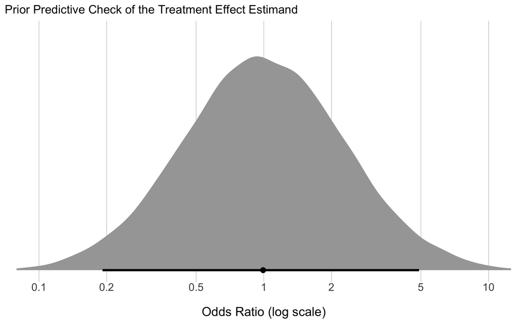

```r
as_draws_df(overall_mod_prior) |>
  ggplot() +
  aes(x = b_treat1) +
  stat_halfeye(.width = 0.95,
               point_interval = median_hdi) +
  scale_x_continuous(
    breaks = c(0.1, 0.2, 0.5, 1, 2, 5, 10) |> log(),
    labels = function(x) exp(x)
    ) +
  coord_cartesian(x = c(0.1, 10) |> log())  +
  labs(x = "\nOdds Ratio (log scale)",
       y = " ",
       title = "Prior Predictive Check of the Treatment Effect Estimand") +
  theme(axis.text.y = element_blank())
```

Fit the full model (data + prior)

```r
overall_mod =
  brm(
    formula = mf,
    family = binomial,
    prior = priors_overall,
    data = long_data,

    control = list(adapt_delta = .95),
    backend = "cmdstanr", # faster
    cores = parallel::detectCores(),
    chains = 4,
    warmup = 5000,
    iter = 10000,
    seed = 123,
    refresh = 0, # omit sampling text
    file = here("models", "overall_mod.Rds"),
    file_refit = "on_change"
)
```

## 4.1 Model Diagnostics

Rhat

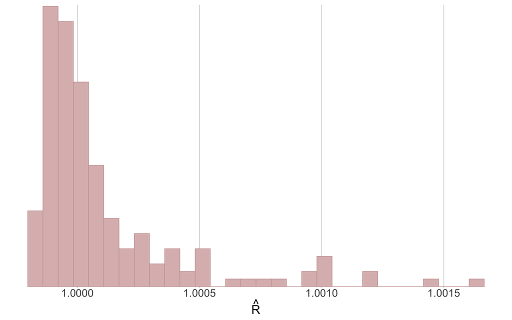

```r
rhat(overall_mod$fit) |>
  mcmc_rhat_hist() +
  theme(legend.position = "none" )
```

Ratios of effective sample size to total sample size

Values are colored using different shades (lighter is better). The chosen thresholds are somewhat arbitrary, but can be useful guidelines in practice.

light: between 0.5 and 1 (high)

mid: between 0.1 and 0.5 (good)

dark: below 0.1 (low)

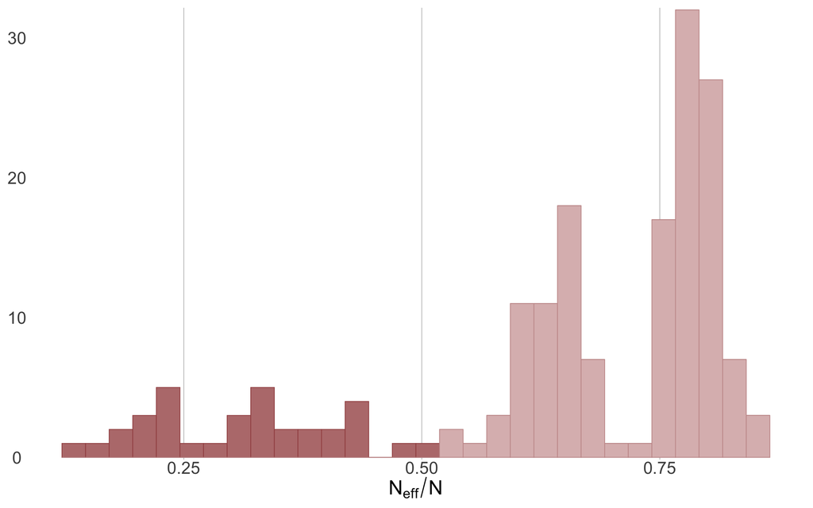

```r
neff_ratio(overall_mod) |>
  mcmc_neff_hist() +
  theme(legend.position = "none" )
```

### 4.1.1 Does the Trace-Plot Exhibit Convergence?

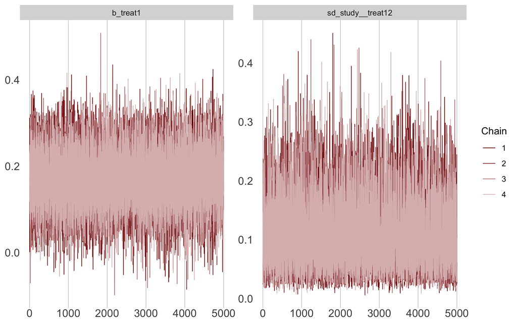

```r
mcmc_trace(overall_mod, pars = c("b_treat1","sd_study__treat12"))
```

### 4.1.2 Does the Histogram Have Enough Information?

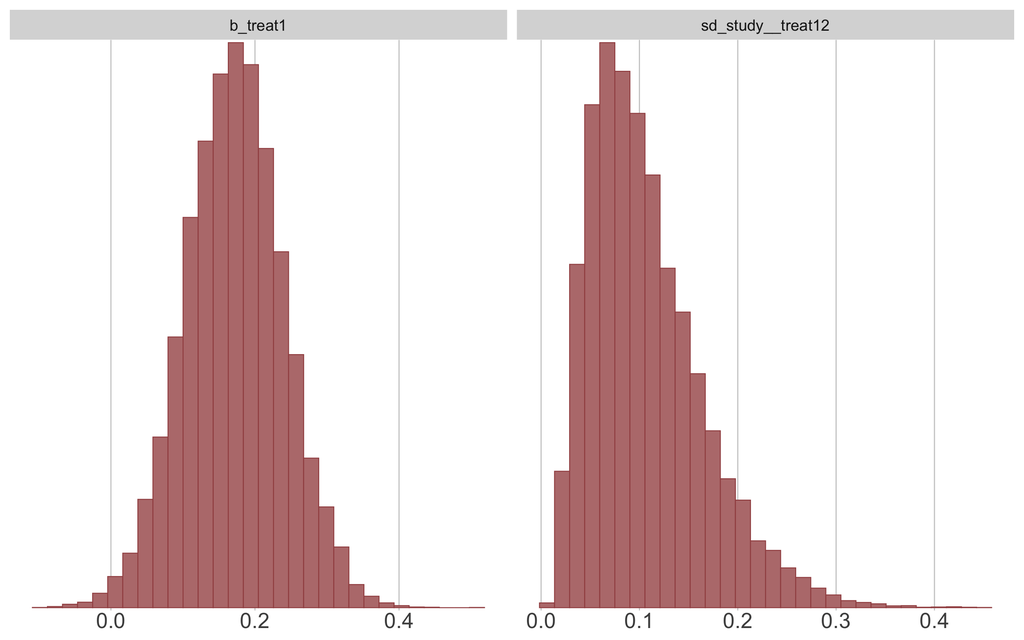

```r
mcmc_hist(overall_mod, pars = c("b_treat1","sd_study__treat12"))
```

### 4.1.3 Do the Chains Exhibit a Strong Degree of Autocorrelation?

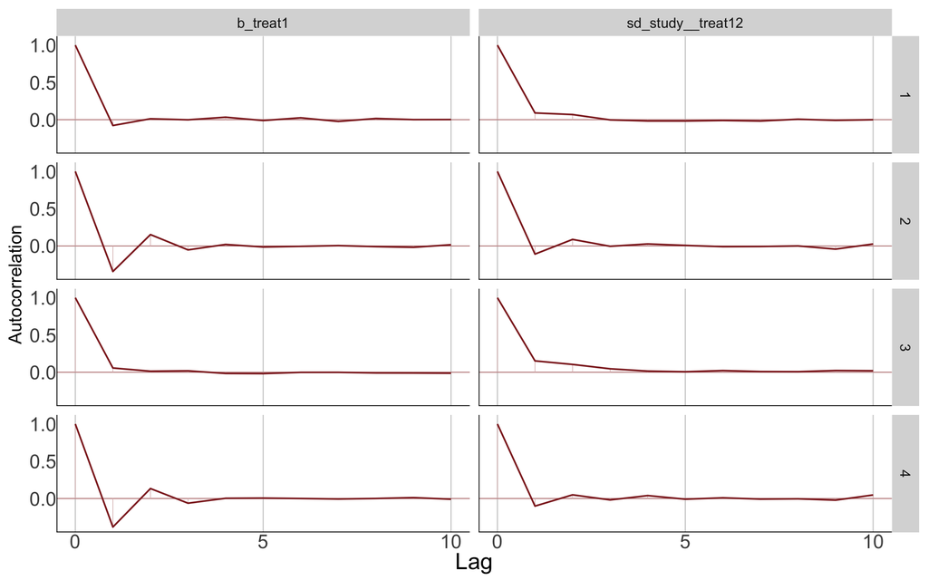

```r
mcmc_acf(overall_mod, pars = c("b_treat1","sd_study__treat12"),
         lags = 10)
```

### 4.1.4 Does the Posterior Distribution Make Substantive Sense?

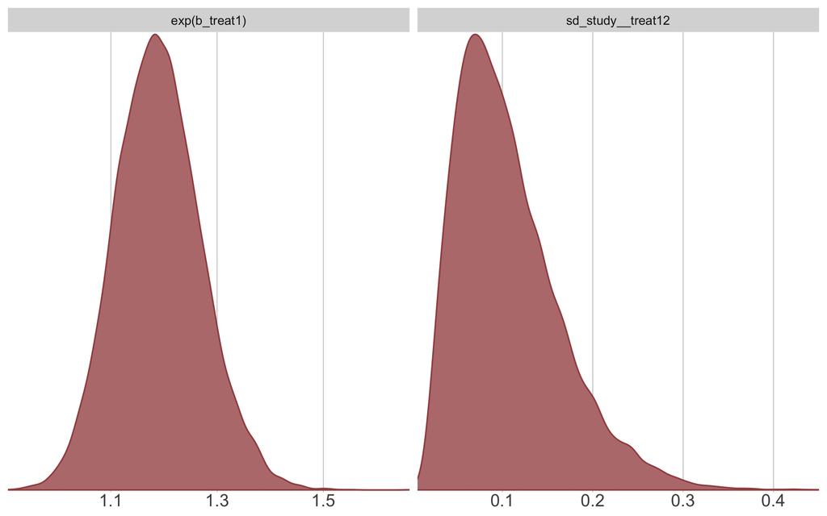

```r
mcmc_dens(overall_mod,
          pars = c("b_treat1","sd_study__treat12"),
          transformations = list("b_treat1" = "exp"))
```

# 5 Meta-Regressions

## 5.1 Clinical Indication

Model formula

```r
# Formula with meta-regression
mf_indication =
  bf(death | trials(N) ~ 1 + study + treat*indication + (treat12 - 1 | study))

# # get_prior(mf_indication, data = long_data, family = binomial)
```

Priors

```r
priors_regression_indication =
  # study's baseline (treat = 0) log odds, when subgroup == "Febrile neutropenia"
  prior(normal(0, 1.5), class = Intercept) +
  prior(normal(0, 1.5), class = b) +
  # treatment effect in reference subgroup "Febrile neutropenia", log odds ratio
  prior(normal(0, 0.82), class = b, coef = "treat1") +
  # change in log-odds when treat = 0 for each subgroup
  prior(normal(0, 1.2), class = b, coef = "indicationMeningitis") +
  prior(normal(0, 1.2), class = b, coef = "indicationMixed") +
  prior(normal(0, 1.2), class = b, coef = "indicationPneumonia") +
  prior(normal(0, 1.2), class = b, coef = "indicationSeverebacterialinfections") +
  prior(normal(0, 1.2), class = b, coef = "indicationUTI") +
  # change in the treatment effect for each subgroup compared to "Febrile neutropenia"
  prior(normal(0, 0.3), class = b, coef = "treat1:indicationMeningitis") +
  prior(normal(0, 0.3), class = b, coef = "treat1:indicationMixed") +
  prior(normal(0, 0.3), class = b, coef = "treat1:indicationPneumonia") +
  prior(normal(0, 0.3), class = b, coef = "treat1:indicationSeverebacterialinfections") +
  prior(normal(0, 0.3), class = b, coef = "treat1:indicationUTI") +
  # between-study SD, "tau"
  prior(lognormal(-2.09, 0.705), class = sd)
```

Fit the model only sampling from prior distributions

```r
indication_mod_prior =
  brm(
    sample_prior = "only",
    formula = mf_indication,
    family = binomial,
    prior = priors_regression_indication,
    data = long_data,

    control = list(adapt_delta = .95),
    backend = "cmdstanr", # faster
    cores = parallel::detectCores(),
    chains = 4,
    warmup = 5000,
    iter = 10000,
    seed = 123,
    refresh = 0, # omit sampling text
    file = here("models", "indication_mod_prior.Rds"),
    file_refit = "on_change"
)
```

Now check if estimand distributions look reasonable (prior predictive check):

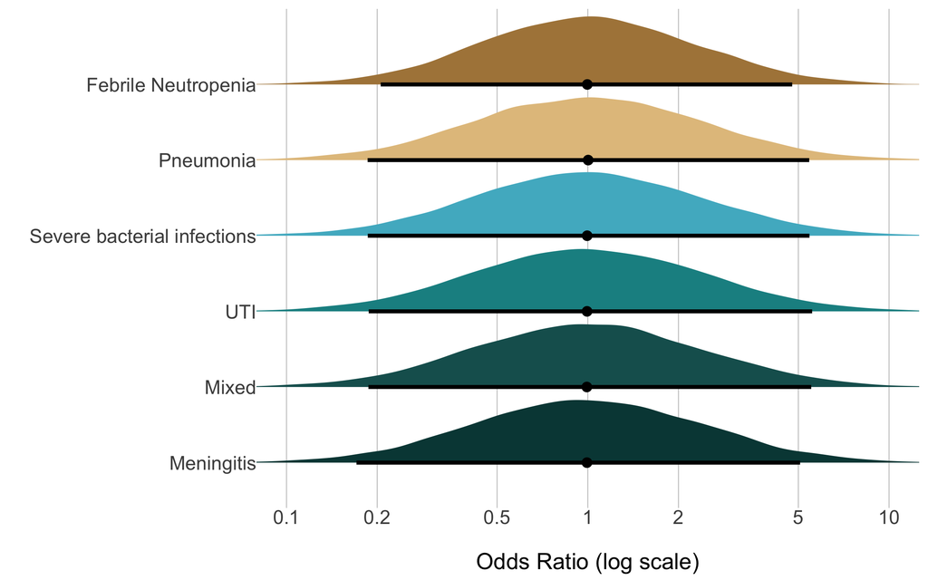

```r
as_draws_df(indication_mod_prior) |>
  reframe("Febrile Neutropenia" = b_treat1,
          "Mixed" = b_treat1 + `b_treat1:indicationMixed`,
          "Pneumonia" = b_treat1 + `b_treat1:indicationPneumonia`,
          "Severe bacterial infections" = b_treat1 + `b_treat1:indicationSeverebacterialinfections`,
          "UTI" = b_treat1 + `b_treat1:indicationUTI`,
          "Meningitis" = b_treat1 + `b_treat1:indicationMeningitis`) |>
  pivot_longer(everything()) |>
  mutate(name = factor(name, levels = c("Febrile Neutropenia",
                                        "Pneumonia",
                                        "Severe bacterial infections",
                                        "UTI",
                                        "Mixed",
                                        "Meningitis") |> rev()
                       )
         ) |>

  ggplot() +
  aes(x = value, y = name, fill = name) +
  stat_halfeye(.width = 0.95,
               point_interval = median_hdi) +
  scale_fill_manual(values=met.brewer("Isfahan1", 8) |> rev()) +
  scale_x_continuous(
    breaks = c(0.1, 0.2, 0.5, 1, 2, 5, 10) |> log(),
    labels = function(x) exp(x)
    ) +
  coord_cartesian(x = c(0.1, 10) |> log())  +
  labs(x = "\nOdds Ratio (log scale)",
       y = " ") +
  theme(legend.position = "none",
        axis.text.y = element_text(hjust = 1))
```

Fit the full model (data + prior)

```r
indication_mod =
  brm(
    formula = mf_indication,
    family = binomial,
    prior = priors_regression_indication,
    data = long_data,

    control = list(adapt_delta = .95),
    backend = "cmdstanr", # faster
    cores = parallel::detectCores(),
    chains = 4,
    warmup = 5000,
    iter = 10000,
    seed = 123,
    refresh = 0, # omit sampling text
    file = here("models", "indication_mod.Rds"),
    file_refit = "on_change"
)
```

### 5.1.1 Model Diagnostics

Rhat

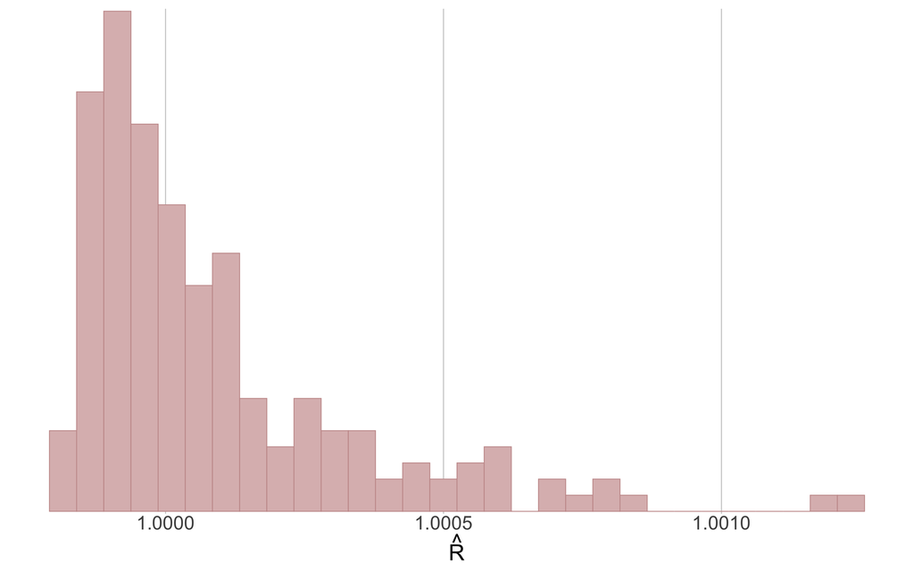

```r
rhat(indication_mod$fit) |>
  mcmc_rhat_hist() +
  theme(legend.position = "none" )
```

Ratios of effective sample size to total sample size

Values are colored using different shades (lighter is better). The chosen thresholds are somewhat arbitrary, but can be useful guidelines in practice.

light: between 0.5 and 1 (high)

mid: between 0.1 and 0.5 (good)

dark: below 0.1 (low)

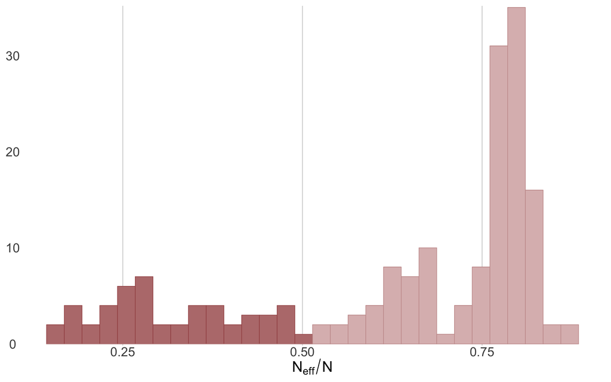

```r
neff_ratio(indication_mod) |>
  mcmc_neff_hist() +
  theme(legend.position = "none" )
```

#### Does the Trace-Plot Exhibit Convergence?

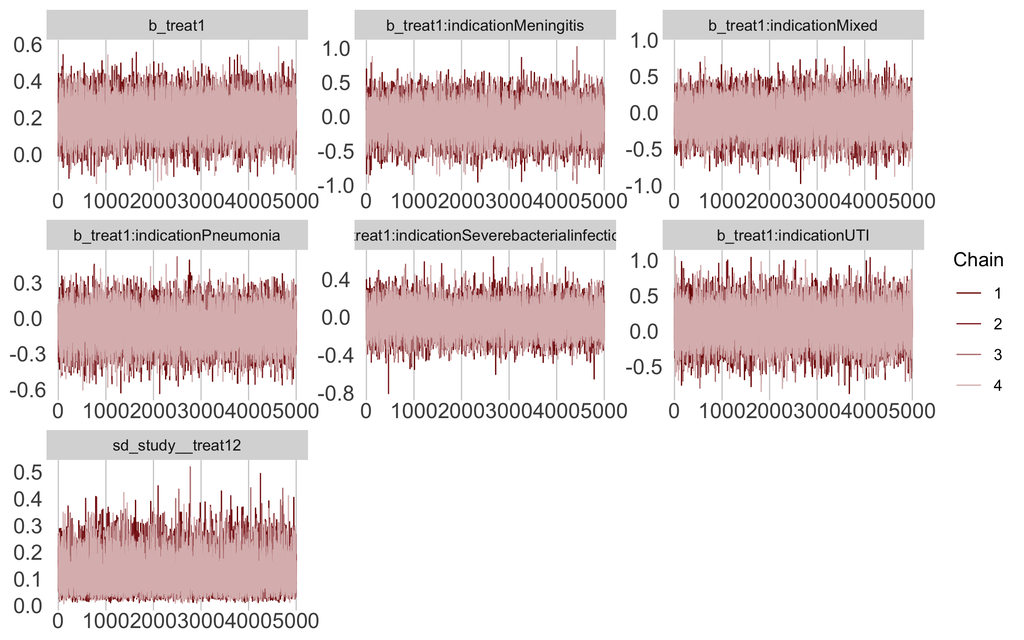

```r
mcmc_trace(indication_mod, pars = c("b_treat1",
                                    "b_treat1:indicationMeningitis",
                                    "b_treat1:indicationMixed",
                                    "b_treat1:indicationPneumonia",
                                    "b_treat1:indicationSeverebacterialinfections",
                                    "b_treat1:indicationUTI",
                                    "sd_study__treat12"))
```

#### Does the Histogram Have Enough Information?

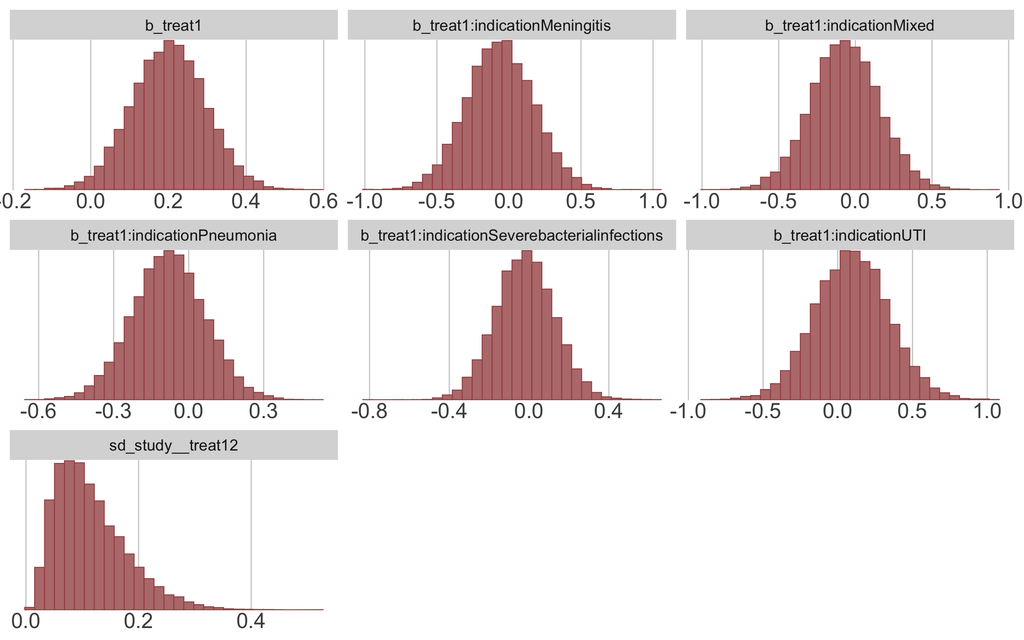

```r
mcmc_hist(indication_mod, pars = c("b_treat1",
                                    "b_treat1:indicationMeningitis",
                                    "b_treat1:indicationMixed",
                                    "b_treat1:indicationPneumonia",
                                    "b_treat1:indicationSeverebacterialinfections",
                                    "b_treat1:indicationUTI",
                                    "sd_study__treat12"))
```

#### Do the Chains Exhibit a Strong Degree of Autocorrelation?

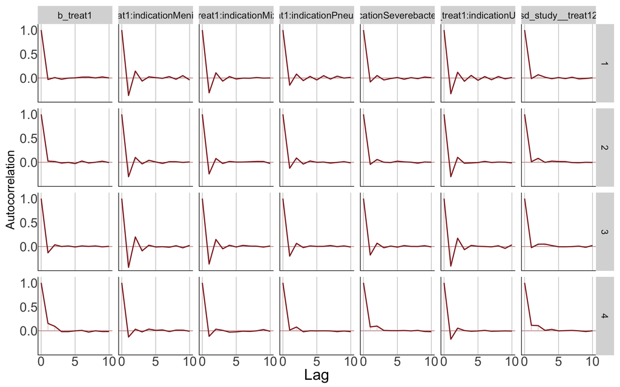

```r
mcmc_acf(indication_mod, pars = c("b_treat1",
                                  "b_treat1:indicationMeningitis",
                                  "b_treat1:indicationMixed",
                                  "b_treat1:indicationPneumonia",
                                  "b_treat1:indicationSeverebacterialinfections",
                                  "b_treat1:indicationUTI",
                                  "sd_study__treat12"),
         lags = 10)
```

#### Does the Posterior Distribution Make Substantive Sense?

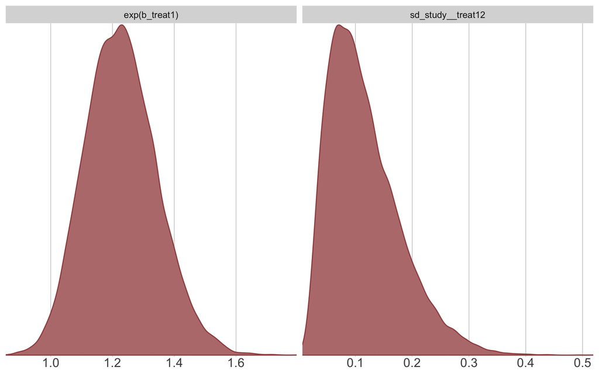

```r
mcmc_dens(indication_mod,
          pars = c("b_treat1",
                   "sd_study__treat12"),
          transformations = list("b_treat1" = "exp"))
```

## 5.2 Comparator Group

Model formula

```r
# Formula with meta-regression
mf_comparator =
  bf(death | trials(N) ~ 1 + study + treat*comparator_group + (treat12 - 1 | study))

#| output: false
# get_prior(mf_comparator, data = long_data, family = binomial)
```

Priors

```r
priors_regression_comparator =
  # study's baseline (treat = 0) log odds when subgroup == "Piperacillin-tazobactam"
  prior(normal(0, 1.5), class = Intercept) +
  prior(normal(0, 1.5), class = b) +
  # treatment effect in reference subgroup "Piperacillin-tazobactam", log odds ratio
  prior(normal(0, 0.82), class = b, coef = "treat1") +
  # change in log-odds when treat = 0 for each subgroup
  prior(normal(0, 1.2), class = b, coef = "comparator_groupCarbapenem") +
  prior(normal(0, 1.2), class = b, coef = "comparator_groupCefotaximeDCeftriaxone") +
  prior(normal(0, 1.2), class = b, coef = "comparator_groupCeftazidime") +
  # change in the treatment effect for each subgroup compared to "Piperacillin-tazobactam"
  prior(normal(0, 0.3), class = b, coef = "treat1:comparator_groupCarbapenem") +
  prior(normal(0, 0.3), class = b, coef = "treat1:comparator_groupCefotaximeDCeftriaxone") +
  prior(normal(0, 0.3), class = b, coef = "treat1:comparator_groupCeftazidime") +
  # between-study SD, "tau"
  prior(lognormal(-2.09, 0.705), class = sd)
```

Fit the model only sampling from prior distributions

```r
comparator_mod_prior =
  brm(
    sample_prior = "only",
    formula = mf_comparator,
    family = binomial,
    prior = priors_regression_comparator,
    data = subset(long_data, !is.na(comparator_group)), # remove NA

    control = list(adapt_delta = .95),
    backend = "cmdstanr", # faster
    cores = parallel::detectCores(),
    chains = 4,
    warmup = 5000,
    iter = 10000,
    seed = 123,
    refresh = 0, # omit sampling text
    file = here("models", "comparator_mod_prior.Rds"),
    file_refit = "on_change"
)
```

Now check if estimand distributions look reasonable (prior predictive check):

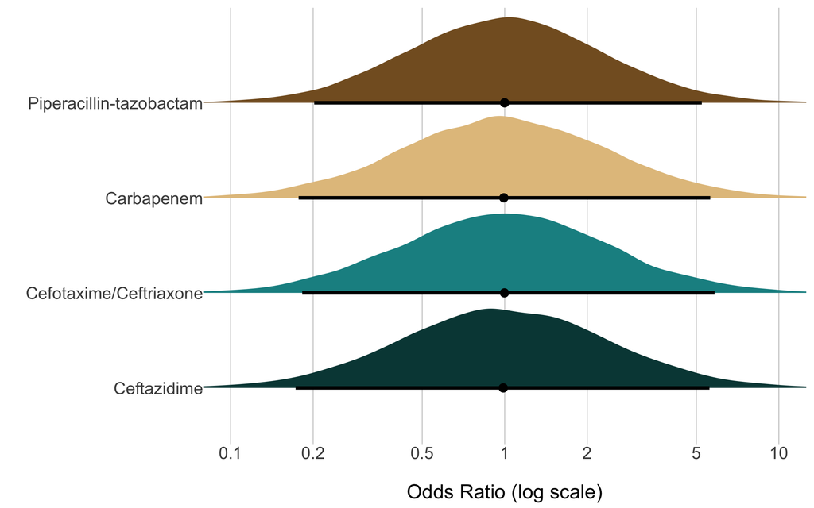

```r
as_draws_df(comparator_mod_prior) |>
  reframe("Piperacillin-tazobactam" = b_treat1,
          "Carbapenem" = b_treat1 + `b_treat1:comparator_groupCarbapenem`,
          "Cefotaxime/Ceftriaxone" = b_treat1 + `b_treat1:comparator_groupCefotaximeDCeftriaxone`,
          "Ceftazidime" = b_treat1 + `b_treat1:comparator_groupCeftazidime`) |>
  pivot_longer(everything()) |>
  mutate(name = factor(name, c("Piperacillin-tazobactam",
                               "Carbapenem",
                               "Cefotaxime/Ceftriaxone",
                               "Ceftazidime") |> rev()
                       )
         ) |>

  ggplot() +
  aes(x = value, y = name, fill = name) +
  stat_halfeye(.width = 0.95,
               point_interval = median_hdi) +
  scale_fill_manual(values=met.brewer("Isfahan1", 4) |> rev()) +
  scale_x_continuous(
    breaks = c(0.1, 0.2, 0.5, 1, 2, 5, 10) |> log(),
    labels = function(x) exp(x)
    ) +
  coord_cartesian(x = c(0.1, 10) |> log())  +
  labs(x = "\nOdds Ratio (log scale)",
       y = " ") +
  theme(legend.position = "none",
        axis.text.y = element_text(hjust = 1))
```

Fit the full model (data + prior)

```r
comparator_mod =
  brm(
    formula = mf_comparator,
    family = binomial,
    prior = priors_regression_comparator,
    data = subset(long_data, !is.na(comparator_group)), # remove NA

    control = list(adapt_delta = .95),
    backend = "cmdstanr", # faster
    cores = parallel::detectCores(),
    chains = 4,
    warmup = 5000,
    iter = 10000,
    seed = 123,
    refresh = 0, # omit sampling text
    file = here("models", "comparator_mod.Rds"),
    file_refit = "on_change"
)
```

### 5.2.1 Model Diagnostics

Rhat

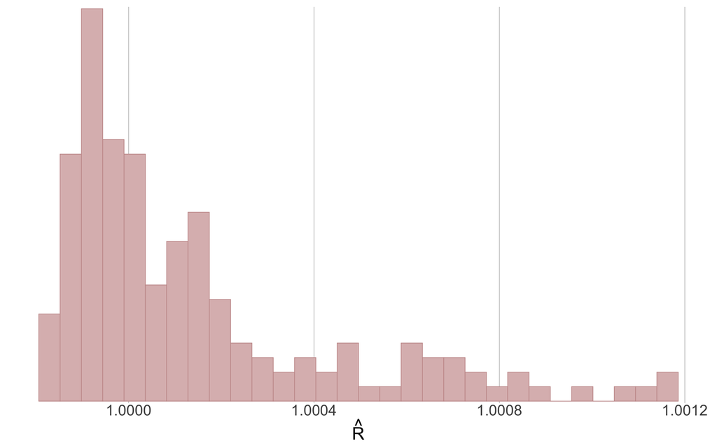

```r
rhat(comparator_mod$fit) |>
  mcmc_rhat_hist() +
  theme(legend.position = "none" )
```

Ratios of effective sample size to total sample size

Values are colored using different shades (lighter is better). The chosen thresholds are somewhat arbitrary, but can be useful guidelines in practice.

light: between 0.5 and 1 (high)

mid: between 0.1 and 0.5 (good)

dark: below 0.1 (low)

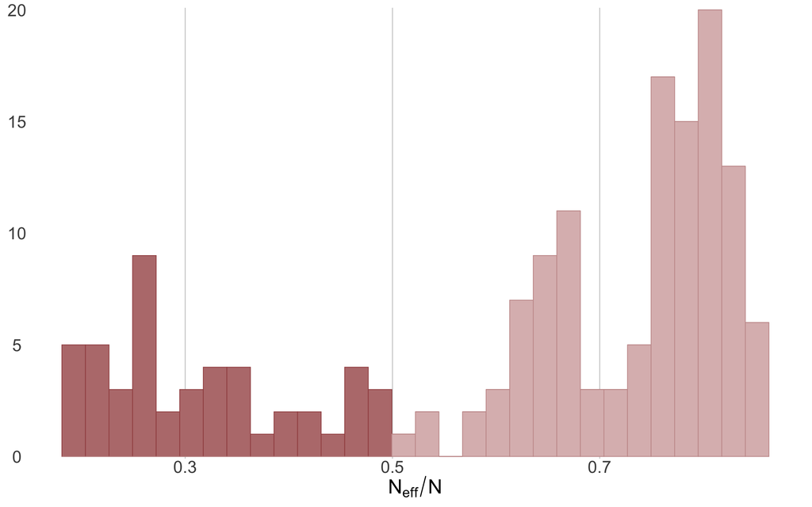

```r
neff_ratio(comparator_mod) |>
  mcmc_neff_hist() +
  theme(legend.position = "none" )
```

#### Does the Trace-Plot Exhibit Convergence?

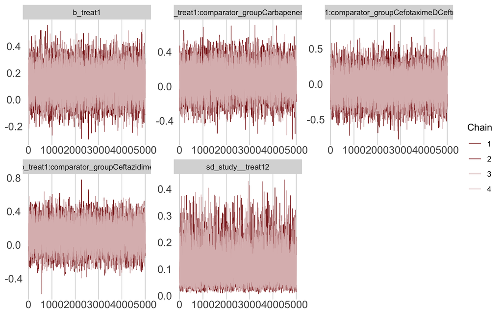

```r
mcmc_trace(comparator_mod, pars = c("b_treat1",
                                    "b_treat1:comparator_groupCarbapenem",
                                    "b_treat1:comparator_groupCefotaximeDCeftriaxone",
                                    "b_treat1:comparator_groupCeftazidime",
                                    "sd_study__treat12"))
```

#### Does the Histogram Have Enough Information?

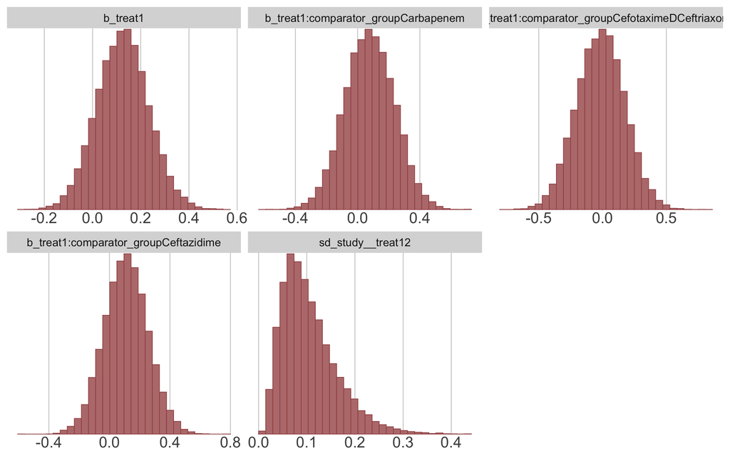

```r
mcmc_hist(comparator_mod, pars = c("b_treat1",
                                    "b_treat1:comparator_groupCarbapenem",
                                    "b_treat1:comparator_groupCefotaximeDCeftriaxone",
                                    "b_treat1:comparator_groupCeftazidime",
                                    "sd_study__treat12"))
```

#### Do the Chains Exhibit a Strong Degree of Autocorrelation?

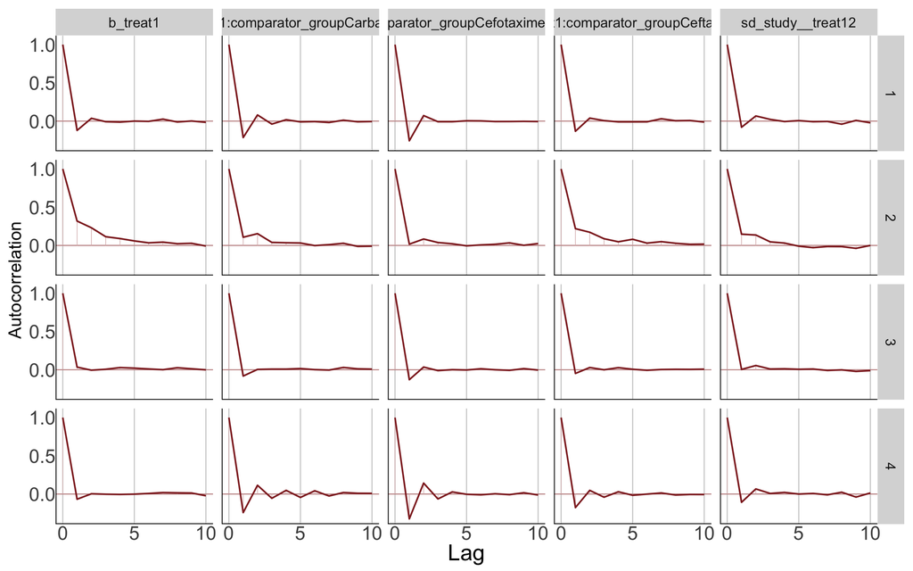

```r
mcmc_acf(comparator_mod, pars = c("b_treat1",
                                    "b_treat1:comparator_groupCarbapenem",
                                    "b_treat1:comparator_groupCefotaximeDCeftriaxone",
                                    "b_treat1:comparator_groupCeftazidime",
                                    "sd_study__treat12"),
         lags = 10)
```

#### Does the Posterior Distribution Make Substantive Sense?

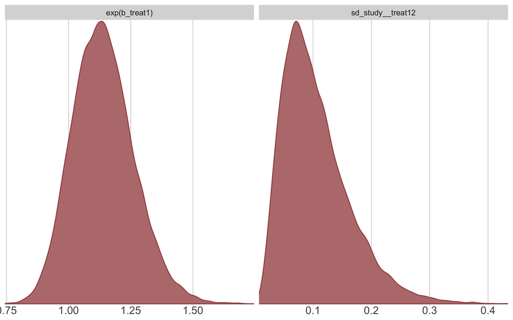

```r
mcmc_dens(comparator_mod,
          pars = c("b_treat1",
                   "sd_study__treat12"),
          transformations = list("b_treat1" = "exp"))
```

## 5.3 Population

Model formula

```r
# Formula with meta-regression
mf_population =
  bf(death | trials(N) ~ 1 + study + treat*population + (treat12 - 1 | study))

#| output: false
# get_prior(mf_population, data = long_data, family = binomial)
```

Priors

```r
priors_regression_population =
  # study's baseline (treat = 0) log odds when subgroup == "Adults"
  prior(normal(0, 1.5), class = Intercept) +
  prior(normal(0, 1.5), class = b) +
  # treatment effect in reference subgroup "Adults", log odds ratio
  prior(normal(0, 0.82), class = b, coef = "treat1") +
  # change in log-odds when treat = 0 for each subgroup
  prior(normal(0, 1.2), class = b, coef = "populationPediatrics") +
  # change in the treatment effect for the "Pediatrics" subgroup
  prior(normal(0, 0.3), class = b, coef = "treat1:populationPediatrics") +
  # between-study SD, "tau"
  prior(lognormal(-2.09, 0.705), class = sd)
```

Fit the model only sampling from prior distributions

```r
population_mod_prior =
  brm(
    sample_prior = "only",
    formula = mf_population,
    family = binomial,
    prior = priors_regression_population,
    data = long_data,

    control = list(adapt_delta = .95),
    backend = "cmdstanr", # faster
    cores = parallel::detectCores(),
    chains = 4,
    warmup = 5000,
    iter = 10000,
    seed = 123,
    refresh = 0, # omit sampling text
    file = here("models", "population_mod_prior.Rds"),
    file_refit = "on_change"
)
```

Now check if estimand distributions look reasonable (prior predictive check):

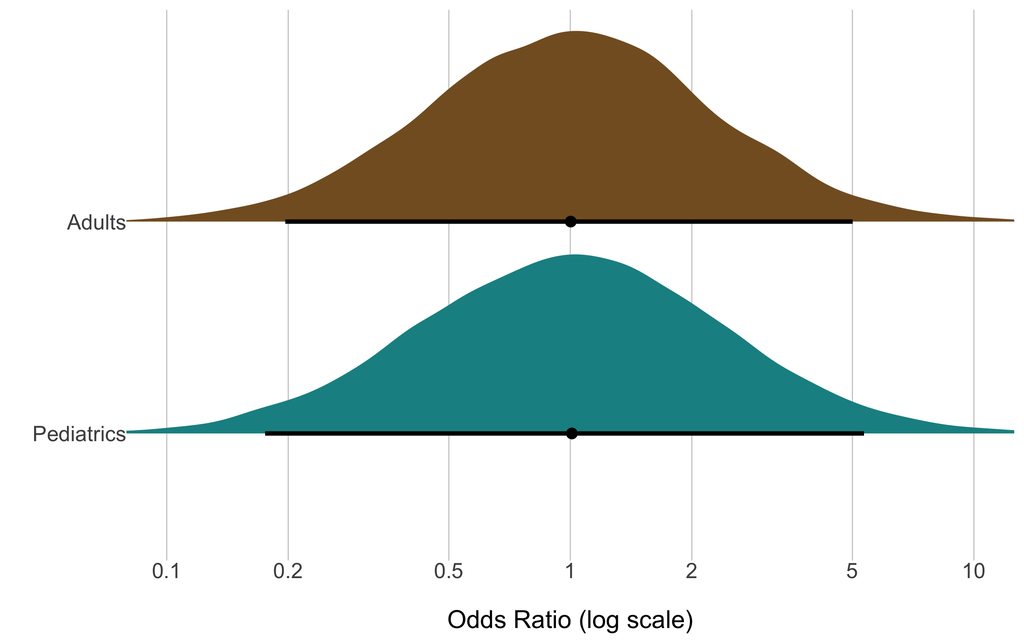

```r
as_draws_df(population_mod_prior) |>
  reframe("Adults" = b_treat1,
          "Pediatrics" = b_treat1 + `b_treat1:populationPediatrics`) |>
  pivot_longer(everything()) |>
  mutate(name = factor(name, c("Adults",
                               "Pediatrics") |> rev()
                       )
         ) |>

  ggplot() +
  aes(x = value, y = name, fill = name) +
  stat_halfeye(.width = 0.95,
               point_interval = median_hdi) +
  scale_fill_manual(values=met.brewer("Isfahan1", 2) |> rev()) +
  scale_x_continuous(
    breaks = c(0.1, 0.2, 0.5, 1, 2, 5, 10) |> log(),
    labels = function(x) exp(x)
    ) +
  coord_cartesian(x = c(0.1, 10) |> log())  +
  labs(x = "\nOdds Ratio (log scale)",
       y = " ") +
  theme(legend.position = "none",
        axis.text.y = element_text(hjust = 1))
```

Fit the full model (data + prior)

```r
population_mod =
  brm(
    formula = mf_population,
    family = binomial,
    prior = priors_regression_population,
    data = long_data,

    control = list(adapt_delta = .95),
    backend = "cmdstanr", # faster
    cores = parallel::detectCores(),
    chains = 4,
    warmup = 5000,
    iter = 10000,
    seed = 123,
    refresh = 0, # omit sampling text
    file = here("models", "population_mod.Rds"),
    file_refit = "on_change"
)
```

### 5.3.1 Model Diagnostics

Rhat

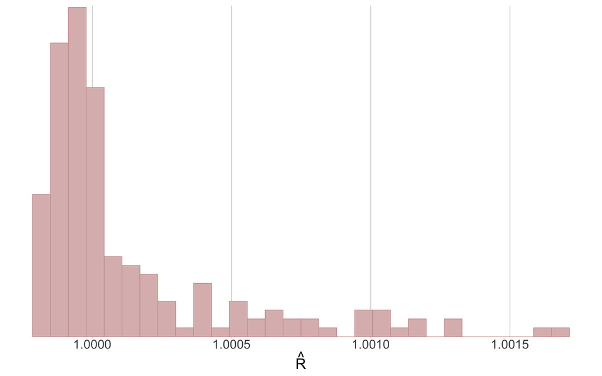

```r
rhat(population_mod$fit) |>
  mcmc_rhat_hist() +
  theme(legend.position = "none" )
```

Ratios of effective sample size to total sample size

Values are colored using different shades (lighter is better). The chosen thresholds are somewhat arbitrary, but can be useful guidelines in practice.

light: between 0.5 and 1 (high)

mid: between 0.1 and 0.5 (good)

dark: below 0.1 (low)

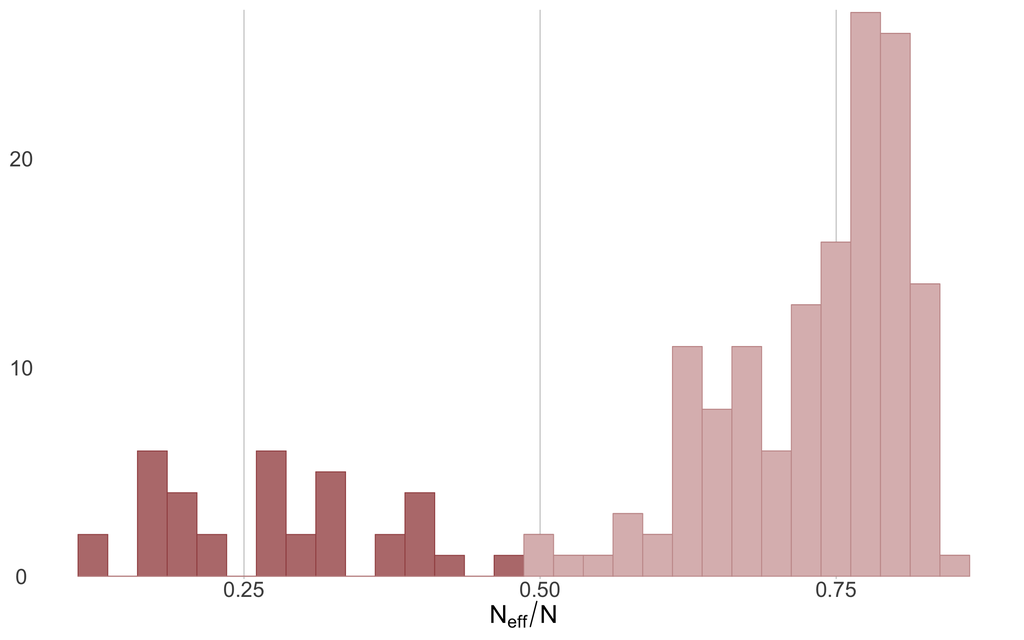

```r
neff_ratio(population_mod) |>
  mcmc_neff_hist() +
  theme(legend.position = "none" )
```

#### Does the Trace-Plot Exhibit Convergence?

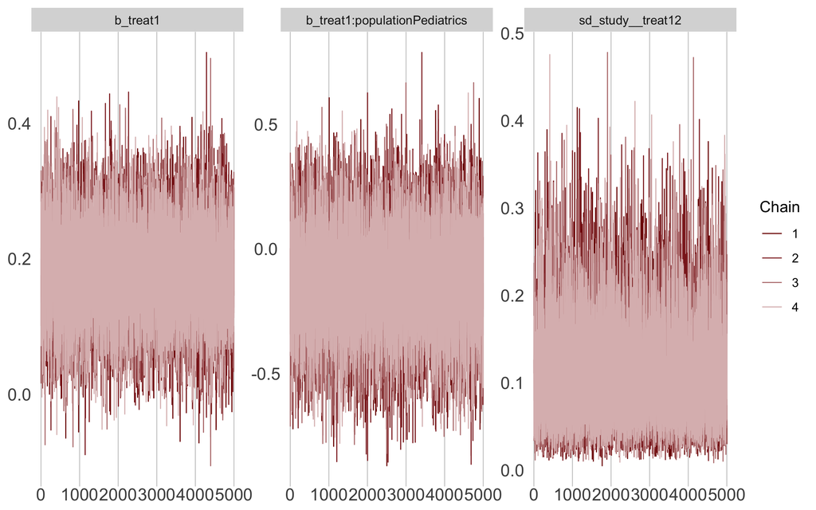

```r
mcmc_trace(population_mod, pars = c("b_treat1",
                                    "b_treat1:populationPediatrics",
                                    "sd_study__treat12"))
```

#### Does the Histogram Have Enough Information?

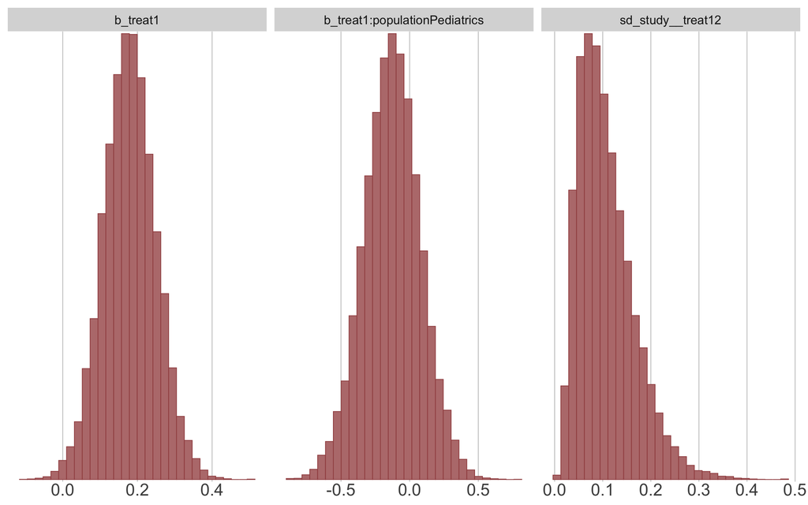

```r
mcmc_hist(population_mod, pars = c("b_treat1",
                                    "b_treat1:populationPediatrics",
                                    "sd_study__treat12"))
```

#### Do the Chains Exhibit a Strong Degree of Autocorrelation?

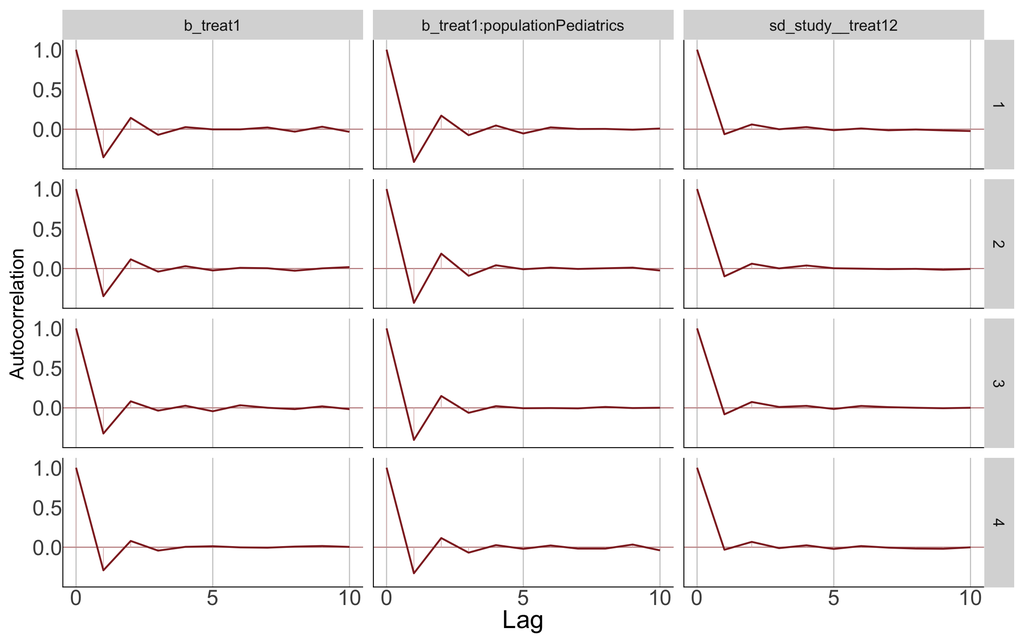

```r
mcmc_acf(population_mod, pars = c("b_treat1",
                                    "b_treat1:populationPediatrics",
                                    "sd_study__treat12"),
         lags = 10)
```

#### Does the Posterior Distribution Make Substantive Sense?

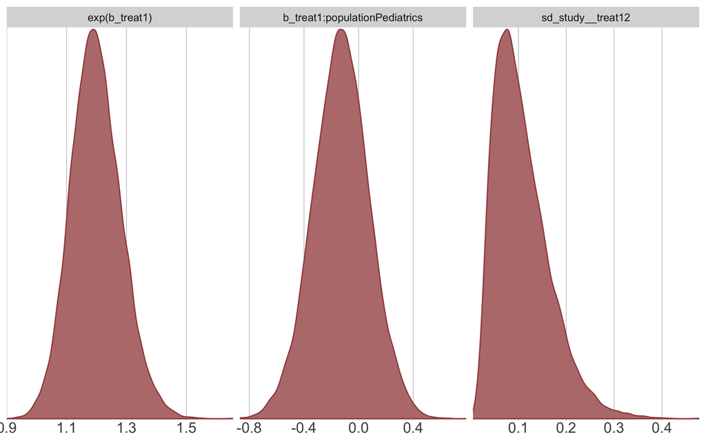

```r
mcmc_dens(population_mod,
          pars = c("b_treat1",
                   "b_treat1:populationPediatrics",
                   "sd_study__treat12"),
          transformations = list("b_treat1" = "exp"))
```

## 5.4 Cefepime Dose

Model formula

```r
# Formula with meta-regression
mf_cefdose =
  bf(death | trials(N) ~ 1 + study + treat*Cefepime_q12 + (treat12 - 1 | study))

#| output: false
# get_prior(mf_cefdose, data = long_data, family = binomial)
```

Priors

```r
priors_regression_cefdose =
  # study's baseline (treat = 0) log odds when subgroup == "High"
  prior(normal(0, 1.5), class = Intercept) +
  prior(normal(0, 1.5), class = b) +
  # treatment effect in reference subgroup "High", log odds ratio
  prior(normal(0, 0.82), class = b, coef = "treat1") +
  # change in log-odds when treat = 0 for each subgroup
  prior(normal(0, 1.2), class = b, coef = "Cefepime_q12Low") +
  # change in the treatment effect for the "Low" subgroup
  prior(normal(0, 0.3), class = b, coef = "treat1:Cefepime_q12Low") +
  # between-study SD, "tau"
  prior(lognormal(-2.09, 0.705), class = sd)
```

Fit the model only sampling from prior distributions

```r
cefdose_mod_prior =
  brm(
    sample_prior = "only",
    formula = mf_cefdose,
    family = binomial,
    prior = priors_regression_cefdose,
    data = subset(long_data, !is.na(Cefepime_q12)), # remove NA,

    control = list(adapt_delta = .95),
    backend = "cmdstanr", # faster
    cores = parallel::detectCores(),
    chains = 4,
    warmup = 5000,
    iter = 10000,
    seed = 123,
    refresh = 0, # omit sampling text
    file = here("models", "cefdose_mod_prior.Rds"),
    file_refit = "on_change"
)
```

Now check if estimand distributions look reasonable (prior predictive check):

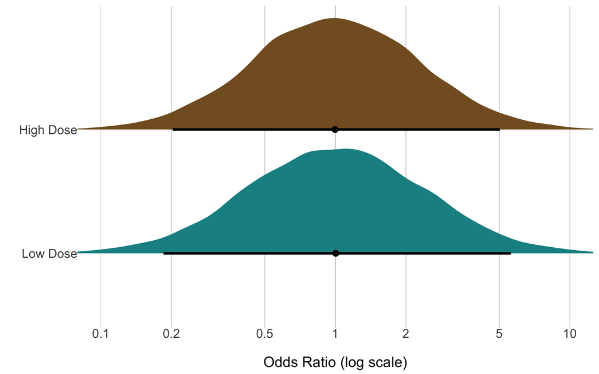

```r
as_draws_df(cefdose_mod_prior) |>
  reframe("High Dose" = b_treat1,
          "Low Dose" = b_treat1 + `b_treat1:Cefepime_q12Low`) |>
  pivot_longer(everything()) |>
  mutate(name = factor(name, c("High Dose",
                               "Low Dose") |> rev()
                       )
         ) |>

  ggplot() +
  aes(x = value, y = name, fill = name) +
  stat_halfeye(.width = 0.95,
               point_interval = median_hdi) +
  scale_fill_manual(values=met.brewer("Isfahan1", 2) |> rev()) +
  scale_x_continuous(
    breaks = c(0.1, 0.2, 0.5, 1, 2, 5, 10) |> log(),
    labels = function(x) exp(x)
    ) +
  coord_cartesian(x = c(0.1, 10) |> log())  +
  labs(x = "\nOdds Ratio (log scale)",
       y = " ") +
  theme(legend.position = "none",
        axis.text.y = element_text(hjust = 1))
```

Fit the full model (data + prior)

```r
cefdose_mod =
  brm(
    formula = mf_cefdose,
    family = binomial,
    prior = priors_regression_cefdose,
    data = subset(long_data, !is.na(Cefepime_q12)), # remove NA,

    control = list(adapt_delta = .95),
    backend = "cmdstanr", # faster
    cores = parallel::detectCores(),
    chains = 4,
    warmup = 5000,
    iter = 10000,
    seed = 123,
    refresh = 0, # omit sampling text
    file = here("models", "cefdose_mod.Rds"),
    file_refit = "on_change"
)
```

### 5.4.1 Model Diagnostics

Rhat

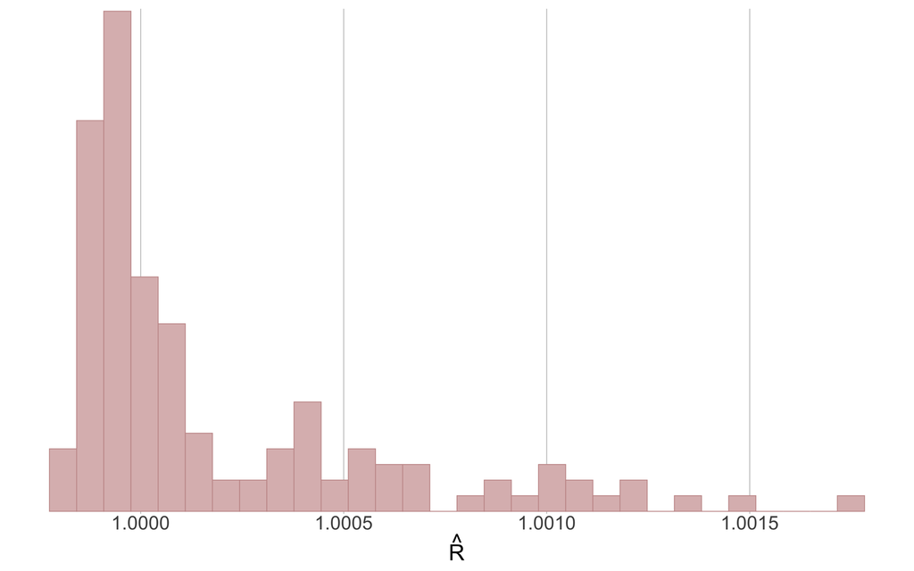

```r
rhat(cefdose_mod$fit) |>
  mcmc_rhat_hist() +
  theme(legend.position = "none" )
```

Ratios of effective sample size to total sample size

Values are colored using different shades (lighter is better). The chosen thresholds are somewhat arbitrary, but can be useful guidelines in practice.

light: between 0.5 and 1 (high)

mid: between 0.1 and 0.5 (good)

dark: below 0.1 (low)

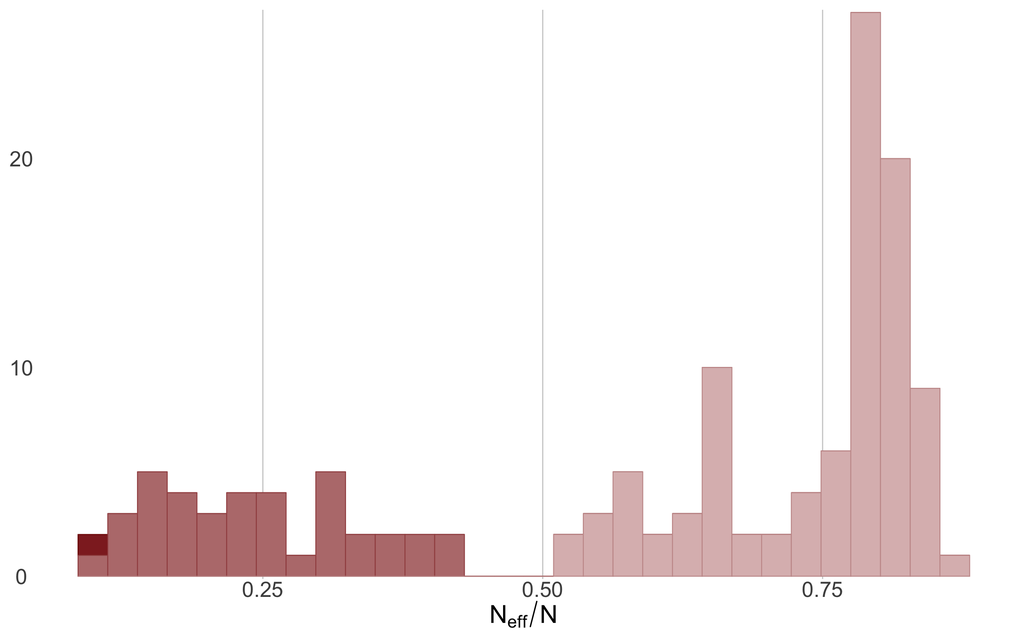

```r
neff_ratio(cefdose_mod) |>
  mcmc_neff_hist() +
  theme(legend.position = "none" )
```

There is a parameter with low Neff/N. Check if most important parameters have high Neff/N:

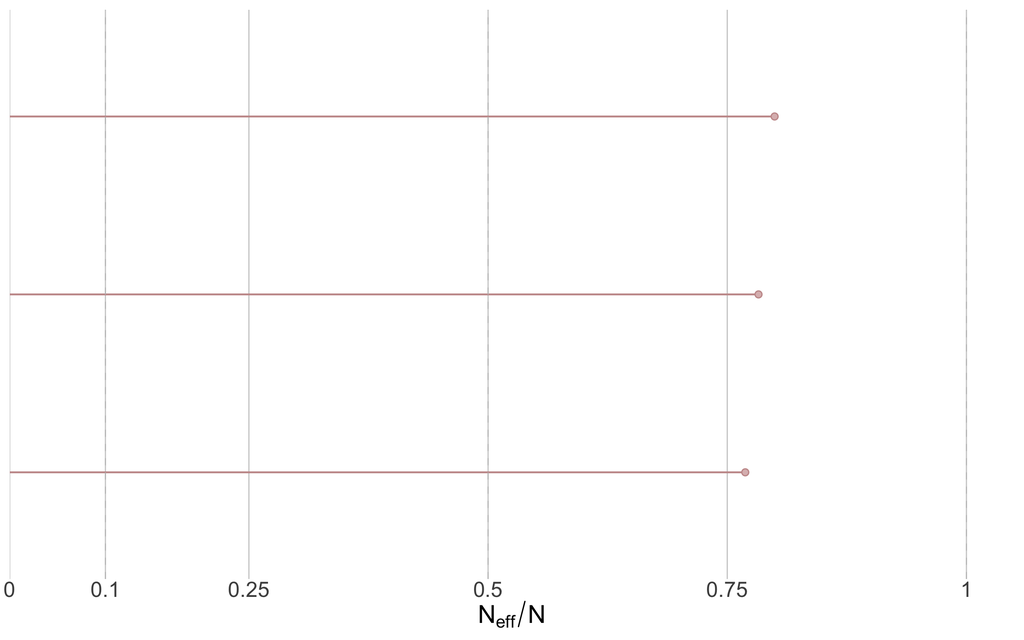

```r
neff_ratio(cefdose_mod, pars = c("b_treat1",
                                    "b_treat1:Cefepime_q12Low",
                                    "sd_study__treat12")) |>
  mcmc_neff() +
  theme(legend.position = "none" )
```